# Thesis Analysis: National Survey (Aug 3-9, 2020)

Nate Bender

11/3/2021

#### Packages / Libraries

#### Load data, filter rejected out

### EDA

#### Respondents / rejected

```r
# Number of respondents / rejects
respondents <- d %>%
  dplyr::filter(reject==0) %>%
  count(respondent_id)

rejected <- d %>%
  dplyr::filter(reject==1) %>%
  count(respondent_id)
```

#### In d_accept: Recoding variable types and renaming where necessary

The response variable for this analysis is #12a: “In the last twelve months, how many times have you taken the following actions related to climate change?”  
Answer option: Contacted elected officials via mail, email, or phone to urge them to take action to reduce climate change."

All explanatory variables were treated as continuous, except for the following that were treated as categorical:  
- #7: What do you believe about climate change?  
- Race  
- Gender  
- Children  
- Marital status  
- Education  
- Employment status  
- Income  
- Religion  
- Political party affiliation  
- Political ideology

#### Listwise deletion

```
## [1] 515  84
```

After listwise deletion, we’re left with 515 responses.

#### Evaluate RV by religion options

```
##
##         catholic  main_protestant      evangelical    oth_christian
##              241               72               61              115
##           mormon        unitarian           jewish           muslim
##                7                2               37               12
##            hindu         buddhist oth_nonchristian        spiritual
##               15               22               11               57
##          atheist         agnostic            other
##               52               71               52
```

```
##
##               catholic main_protestant evangelical oth_christian     mormon
##   nocontact 0.81932773      0.83333333  0.86885246    0.82456140 0.71428571
##   once      0.12605042      0.11111111  0.08196721    0.11403509 0.14285714
##   moreonce  0.05462185      0.05555556  0.04918033    0.06140351 0.14285714
##
##              unitarian     jewish     muslim      hindu   buddhist
##   nocontact 1.00000000 0.83783784 0.83333333 0.80000000 0.80952381
##   once      0.00000000 0.10810811 0.00000000 0.20000000 0.14285714
##   moreonce  0.00000000 0.05405405 0.16666667 0.00000000 0.04761905
##
##             oth_nonchristian  spiritual    atheist   agnostic      other
##   nocontact       0.90909091 0.82456140 0.76923077 0.76056338 0.80000000
##   once            0.09090909 0.08771930 0.17307692 0.12676056 0.10000000
##   moreonce        0.00000000 0.08771930 0.05769231 0.11267606 0.10000000
```

First table is total responses by religion answer choice.

Second table is percentage of RV choice for each religion option.

I’m not seeing major differences in contact rate between different religions. Possibly a difference between religious & non-religious, so I’m going to condense this question into two groups: Religious (all religions; categorized as “1”) and Non-religious (spiritual, atheist, agnostic, other; categorized as “0”).

```
##
##   0   1
## 125 390
```

```
##
##                      0          1
##   nocontact 0.78400000 0.85897436
##   once      0.13600000 0.08717949
##   moreonce  0.08000000 0.05384615
```

After condensing to two groups we see 390 responses have some sort of religion (“1” category), while 125 responses are not religious, with non-religious people potentially more likely to contact elected reps.

#### Evaluate RV by race

“1” is white (question was “check all that apply”; if respondent selected white along w/ any other options they were categorized as white). At this point we don’t see much response difference by race.

#### Evaluate RV by gender

Gender: since there are so few “other” and “prefer not to answer” responses, should I just consider excluding those and limit the analysis to just male and female?

Children: For this analysis I have condensed the children variable to two groups: have children of any age (categorized as “1”), and no children (“0”)

#### Descriptive stats summary

We initially received 1,410 surveys at least partially completed. After filtering 355 responses that did not meet quality control criteria such as straight-lining or finishing the survey unrealistically quickly, we were left with a dataset of 1055 responses. After removing respondents with incomplete data, we were left with a final dataset of 515 responses for analysis.

Respondents were balanced gender-wise, with 48.9% male and 48.7 female, but whites are overrepresented racially, with 79% white, and the sample is highly educated: 65% have a bachelor’s degree or higher.

#### Checking missing values

#### Checking missing values

#### Gender breakdown:

#### Desc stats tables

# Principal Components Analysis

$$\\[.05in]$$
### Dynamic Norms *“Do you think that over the PAST/NEXT 12 months the percentage of adults in the United States who contacted elected officials to urge them to take action to reduce global warming is…”*

One factor solution:  
1. Two-item factor consisting of the two dynamic norms questions (changes in the number of ppl contacting reps in the past and future)

```
##
##  Spearman's rank correlation rho
##
## data:  OLR_complete_cases$sr_24_past_contact and OLR_complete_cases$sr_25_future_contact
## S = 7318162, p-value < 2.2e-16
## alternative hypothesis: true rho is not equal to 0
## sample estimates:
##       rho
## 0.6785354
```

Correlation test of the two dynamic norms items shows strong positive correlation, with Spearman’s rho of 0.6785354 and p-value of 9.737716110^{-71}.

$$\\[.05in]$$

### Descriptive Norms (contact)

*“To what extent do you think that the following people ARE CONTACTING (writing letters, emailing, or calling) their elected representatives in Congress to urge action on reducing climate change?”*

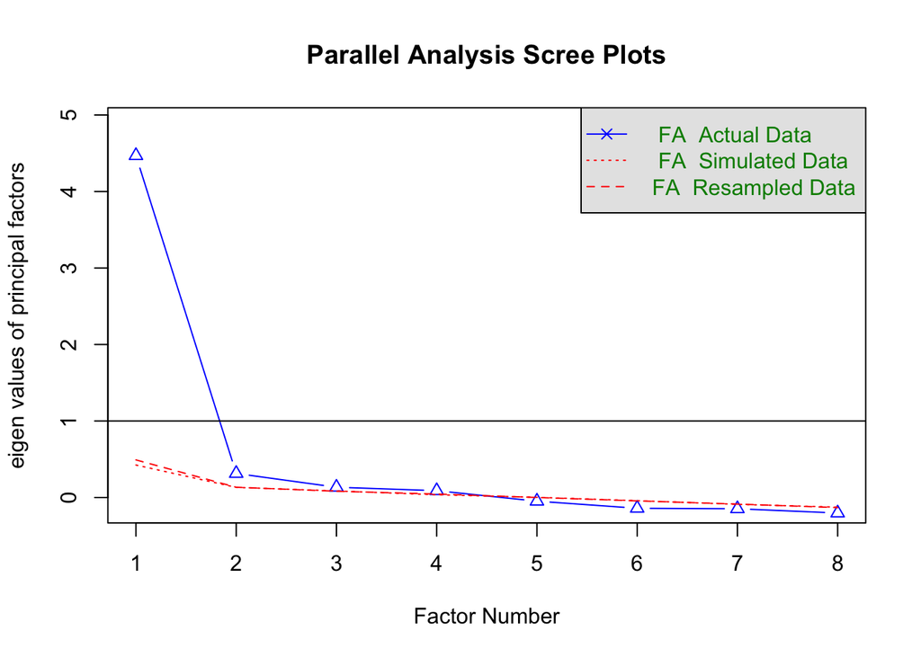

```
## Parallel analysis suggests that the number of factors =  4  and the number of components =  NA
```

```
## Factor Analysis using method =  minres
## Call: fa(r = d_pca_descriptivecontactnorms, nfactors = 4, rotate = "Varimax",
##     fm = "minres")
## Standardized loadings (pattern matrix) based upon correlation matrix
##                                          MR1  MR2  MR3  MR4   h2   u2 com
## sr_19a_contacting_officials_parents     0.27 0.22 0.75 0.16 0.71 0.29 1.6
## sr_19b_contacting_officials_spouse      0.34 0.64 0.26 0.09 0.60 0.40 2.0
## sr_19c_contacting_officials_children    0.25 0.79 0.17 0.22 0.76 0.24 1.5
## sr_19d_contacting_officials_otherfamily 0.62 0.41 0.31 0.13 0.66 0.34 2.4
## sr_19e_contacting_officials_friends     0.88 0.22 0.20 0.17 0.89 0.11 1.3
## sr_19f_contacting_officials_coworkers   0.49 0.21 0.35 0.53 0.69 0.31 3.1
## sr_19g_contacting_officials_recpartners 0.68 0.32 0.18 0.38 0.75 0.25 2.3
## sr_19h_contacting_officials_faithcommun 0.37 0.48 0.16 0.53 0.68 0.32 3.0
##
##                        MR1  MR2  MR3  MR4
## SS loadings           2.26 1.67 0.97 0.85
## Proportion Var        0.28 0.21 0.12 0.11
## Cumulative Var        0.28 0.49 0.61 0.72
## Proportion Explained  0.39 0.29 0.17 0.15
## Cumulative Proportion 0.39 0.68 0.85 1.00
##
## Mean item complexity =  2.1
## Test of the hypothesis that 4 factors are sufficient.
##
## The degrees of freedom for the null model are  28  and the objective function was  4.82 with Chi Square of  2462.01
## The degrees of freedom for the model are 2  and the objective function was  0.02
##
## The root mean square of the residuals (RMSR) is  0.01
## The df corrected root mean square of the residuals is  0.02
##
## The harmonic number of observations is  515 with the empirical chi square  1.26  with prob <  0.53
## The total number of observations was  515  with Likelihood Chi Square =  7.85  with prob <  0.02
##
## Tucker Lewis Index of factoring reliability =  0.966
## RMSEA index =  0.075  and the 90 % confidence intervals are  0.026 0.134
## BIC =  -4.64
## Fit based upon off diagonal values = 1
## Measures of factor score adequacy
##                                                    MR1  MR2  MR3  MR4
## Correlation of (regression) scores with factors   0.92 0.85 0.79 0.72
## Multiple R square of scores with factors          0.84 0.73 0.62 0.52
## Minimum correlation of possible factor scores     0.68 0.46 0.24 0.04
```

```
##
## Loadings:
##                                         MR1   MR2   MR3   MR4
## sr_19a_contacting_officials_parents                 0.748
## sr_19b_contacting_officials_spouse      0.344 0.638
## sr_19c_contacting_officials_children          0.788
## sr_19d_contacting_officials_otherfamily 0.619 0.408 0.310
## sr_19e_contacting_officials_friends     0.883
## sr_19f_contacting_officials_coworkers   0.487       0.350 0.535
## sr_19g_contacting_officials_recpartners 0.680 0.325       0.384
## sr_19h_contacting_officials_faithcommun 0.373 0.481       0.529
##
##                  MR1   MR2   MR3   MR4
## SS loadings    2.257 1.671 0.972 0.845
## Proportion Var 0.282 0.209 0.121 0.106
## Cumulative Var 0.282 0.491 0.612 0.718
```

```
##  sr_19a_contacting_officials_parents sr_19b_contacting_officials_spouse
##  Min.   :1.000                       Min.   :1.000
##  1st Qu.:1.000                       1st Qu.:1.000
##  Median :1.000                       Median :1.000
##  Mean   :2.437                       Mean   :2.256
##  3rd Qu.:5.000                       3rd Qu.:3.500
##  Max.   :5.000                       Max.   :5.000
##  sr_19c_contacting_officials_children sr_19d_contacting_officials_otherfamily
##  Min.   :1.000                        Min.   :1.00
##  1st Qu.:1.000                        1st Qu.:1.00
##  Median :2.000                        Median :1.00
##  Mean   :2.687                        Mean   :2.13
##  3rd Qu.:5.000                        3rd Qu.:3.00
##  Max.   :5.000                        Max.   :5.00
##  sr_19e_contacting_officials_friends sr_19f_contacting_officials_coworkers
##  Min.   :1.000                       Min.   :1.000
##  1st Qu.:1.000                       1st Qu.:1.000
##  Median :1.000                       Median :2.000
##  Mean   :2.144                       Mean   :2.555
##  3rd Qu.:3.000                       3rd Qu.:5.000
##  Max.   :5.000                       Max.   :5.000
##  sr_19g_contacting_officials_recpartners
##  Min.   :1.00
##  1st Qu.:1.00
##  Median :1.00
##  Mean   :2.26
##  3rd Qu.:3.00
##  Max.   :5.00
##  sr_19h_contacting_officials_faithcommun
##  Min.   :1.000
##  1st Qu.:1.000
##  Median :2.000
##  Mean   :2.662
##  3rd Qu.:5.000
##  Max.   :5.000
```

#### Descriptive Norms (contact) - 1st factor (Parents) - desc stats

```r
mean(OLR_complete_cases$sr_19a_contacting_officials__parents)
```

```
## [1] NA
```

```r
sd(OLR_complete_cases$sr_19a_contacting_officials__parents)
```

```
## [1] NA
```

#### Descriptive Norms (contact) - 2nd factor (Spouse & Children) - Correlation & desc stats

```
##
##  Spearman's rank correlation rho
##
## data:  OLR_complete_cases$sr_19b_contacting_officials_spouse and OLR_complete_cases$sr_19c_contacting_officials_children
## S = 7803027, p-value < 2.2e-16
## alternative hypothesis: true rho is not equal to 0
## sample estimates:
##       rho
## 0.6572367
```

Correlation test of the two descriptive norms items for Spouse and Children, showing moderate positive correlation. Spearman’s rho is 0.6572367 with a p-value of 5.321325610^{-65}.

#### Descriptive Norms (contact) - 3rd factor (Non-immediate family) - Cronbach Alpha

```
##
## Reliability analysis
## Call: psych::alpha(x = d_pca_descriptivecontactnormsnonfamily, na.rm = TRUE,
##     use = "pairwise")
##
##   raw_alpha std.alpha G6(smc) average_r S/N    ase mean  sd median_r
##        0.9       0.9    0.89      0.64 8.8 0.0073  2.4 1.4     0.64
##
##  lower alpha upper     95% confidence boundaries
## 0.88 0.9 0.91
##
##  Reliability if an item is dropped:
##                                         raw_alpha std.alpha G6(smc) average_r
## sr_19d_contacting_officials_otherfamily      0.88      0.88    0.86      0.65
## sr_19e_contacting_officials_friends          0.87      0.87    0.83      0.62
## sr_19f_contacting_officials_coworkers        0.88      0.88    0.86      0.65
## sr_19g_contacting_officials_recpartners      0.86      0.86    0.83      0.61
## sr_19h_contacting_officials_faithcommun      0.89      0.89    0.87      0.67
##                                         S/N alpha se  var.r med.r
## sr_19d_contacting_officials_otherfamily 7.4   0.0088 0.0050  0.64
## sr_19e_contacting_officials_friends     6.5   0.0097 0.0024  0.63
## sr_19f_contacting_officials_coworkers   7.4   0.0090 0.0079  0.65
## sr_19g_contacting_officials_recpartners 6.2   0.0103 0.0043  0.60
## sr_19h_contacting_officials_faithcommun 8.1   0.0081 0.0048  0.66
##
##  Item statistics
##                                           n raw.r std.r r.cor r.drop mean  sd
## sr_19d_contacting_officials_otherfamily 515  0.82  0.83  0.77   0.72  2.1 1.5
## sr_19e_contacting_officials_friends     515  0.86  0.87  0.85   0.79  2.1 1.5
## sr_19f_contacting_officials_coworkers   515  0.84  0.83  0.77   0.73  2.6 1.7
## sr_19g_contacting_officials_recpartners 515  0.88  0.89  0.86   0.81  2.3 1.6
## sr_19h_contacting_officials_faithcommun 515  0.81  0.80  0.72   0.68  2.7 1.8
##
## Non missing response frequency for each item
##                                            1    2    3    4    5 miss
## sr_19d_contacting_officials_otherfamily 0.58 0.09 0.11 0.06 0.17    0
## sr_19e_contacting_officials_friends     0.52 0.15 0.13 0.05 0.15    0
## sr_19f_contacting_officials_coworkers   0.48 0.09 0.11 0.05 0.28    0
## sr_19g_contacting_officials_recpartners 0.54 0.10 0.11 0.05 0.20    0
## sr_19h_contacting_officials_faithcommun 0.45 0.09 0.11 0.04 0.31    0
```

$$\\[.05in]$$

### Descriptive Norms (role models)

*“How likely are you to consider each of these groups as behavioral role models?”*

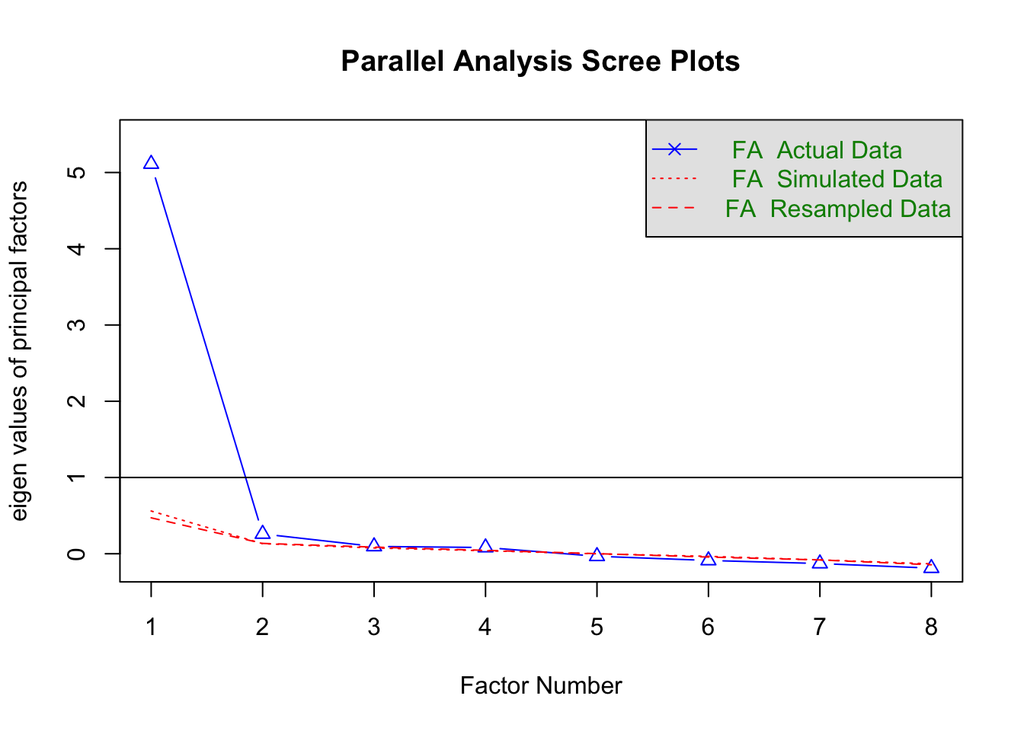

```
## Parallel analysis suggests that the number of factors =  2  and the number of components =  NA
```

```
## Factor Analysis using method =  minres
## Call: fa(r = d_pca_descriptiverolemodelnorms, nfactors = 4, rotate = "Varimax",
##     fm = "minres")
## Standardized loadings (pattern matrix) based upon correlation matrix
##                                MR1  MR3  MR2  MR4   h2     u2 com
## sr_20a_rolemodels_parents     0.26 0.24 0.92 0.12 1.00 0.0034 1.3
## sr_20b_rolemodels_spouse      0.39 0.58 0.39 0.11 0.65 0.3528 2.7
## sr_20c_rolemodels_children    0.30 0.89 0.25 0.15 0.97 0.0309 1.4
## sr_20d_rolemodels_otherfamily 0.68 0.37 0.33 0.17 0.73 0.2653 2.2
## sr_20e_rolemodels_friends     0.86 0.30 0.27 0.12 0.91 0.0865 1.5
## sr_20f_rolemodels_coworkers   0.48 0.29 0.39 0.43 0.65 0.3462 3.6
## sr_20g_rolemodels_recpartners 0.68 0.33 0.29 0.35 0.78 0.2224 2.5
## sr_20h_rolemodels_faithcommun 0.41 0.49 0.26 0.49 0.71 0.2892 3.5
##
##                        MR1  MR3  MR2  MR4
## SS loadings           2.36 1.85 1.55 0.63
## Proportion Var        0.30 0.23 0.19 0.08
## Cumulative Var        0.30 0.53 0.72 0.80
## Proportion Explained  0.37 0.29 0.24 0.10
## Cumulative Proportion 0.37 0.66 0.90 1.00
##
## Mean item complexity =  2.3
## Test of the hypothesis that 4 factors are sufficient.
##
## The degrees of freedom for the null model are  28  and the objective function was  6.13 with Chi Square of  3130.28
## The degrees of freedom for the model are 2  and the objective function was  0.01
##
## The root mean square of the residuals (RMSR) is  0.01
## The df corrected root mean square of the residuals is  0.02
##
## The harmonic number of observations is  515 with the empirical chi square  0.75  with prob <  0.69
## The total number of observations was  515  with Likelihood Chi Square =  6.68  with prob <  0.035
##
## Tucker Lewis Index of factoring reliability =  0.979
## RMSEA index =  0.067  and the 90 % confidence intervals are  0.015 0.127
## BIC =  -5.81
## Fit based upon off diagonal values = 1
## Measures of factor score adequacy
##                                                    MR1  MR3  MR2   MR4
## Correlation of (regression) scores with factors   0.93 0.97 0.99  0.69
## Multiple R square of scores with factors          0.87 0.94 0.99  0.48
## Minimum correlation of possible factor scores     0.75 0.87 0.97 -0.05
```

```
##
## Loadings:
##                               MR1   MR3   MR2   MR4
## sr_20a_rolemodels_parents                 0.924
## sr_20b_rolemodels_spouse      0.388 0.576 0.390
## sr_20c_rolemodels_children          0.893
## sr_20d_rolemodels_otherfamily 0.678 0.370 0.332
## sr_20e_rolemodels_friends     0.858 0.301
## sr_20f_rolemodels_coworkers   0.485       0.389 0.426
## sr_20g_rolemodels_recpartners 0.677 0.333       0.349
## sr_20h_rolemodels_faithcommun 0.411 0.489       0.486
##
##                  MR1   MR3   MR2   MR4
## SS loadings    2.364 1.853 1.554 0.632
## Proportion Var 0.296 0.232 0.194 0.079
## Cumulative Var 0.296 0.527 0.721 0.800
```

#### Descriptive Norms (role models) - 1st factor (Parents) - Descriptive stats

```
## [1] 3.951456
```

```
## [1] 1.746473
```

#### Descriptive Norms (role models) - 2nd factor (Spouse & Children) - Correlation

```
##
##  Spearman's rank correlation rho
##
## data:  OLR_complete_cases$sr_20b_rolemodels_spouse and OLR_complete_cases$sr_20c_rolemodels_children
## S = 6743847, p-value < 2.2e-16
## alternative hypothesis: true rho is not equal to 0
## sample estimates:
##       rho
## 0.7037633
```

```
## [1] 4.001942
```

```
## [1] 1.680165
```

```
## [1] 4.100971
```

```
## [1] 1.803989
```

Correlation test of the two descriptive norms items for Spouse and Children, showing moderate positive correlation. Spearman’s rho is 0.7037633 with a p-value of 3.390290910^{-78}.

#### Descriptive Norms (role models) - 3rd factor (Non-immediate family) - Cronbach Alpha

```
##
## Reliability analysis
## Call: psych::alpha(x = d_pca_descriptivecontactnormsnonfamily, na.rm = TRUE,
##     use = "pairwise")
##
##   raw_alpha std.alpha G6(smc) average_r S/N    ase mean  sd median_r
##       0.92      0.92    0.91      0.69  11 0.0059  3.6 1.5     0.68
##
##  lower alpha upper     95% confidence boundaries
## 0.9 0.92 0.93
##
##  Reliability if an item is dropped:
##                               raw_alpha std.alpha G6(smc) average_r  S/N
## sr_20d_rolemodels_otherfamily      0.90      0.90    0.87      0.69  8.8
## sr_20e_rolemodels_friends          0.89      0.89    0.86      0.67  8.2
## sr_20f_rolemodels_coworkers        0.91      0.91    0.89      0.71 10.0
## sr_20g_rolemodels_recpartners      0.89      0.89    0.87      0.67  8.0
## sr_20h_rolemodels_faithcommun      0.91      0.91    0.89      0.72 10.4
##                               alpha se  var.r med.r
## sr_20d_rolemodels_otherfamily   0.0076 0.0035  0.68
## sr_20e_rolemodels_friends       0.0079 0.0019  0.67
## sr_20f_rolemodels_coworkers     0.0069 0.0063  0.71
## sr_20g_rolemodels_recpartners   0.0083 0.0047  0.64
## sr_20h_rolemodels_faithcommun   0.0066 0.0050  0.72
##
##  Item statistics
##                                 n raw.r std.r r.cor r.drop mean  sd
## sr_20d_rolemodels_otherfamily 515  0.87  0.88  0.84   0.80  3.4 1.6
## sr_20e_rolemodels_friends     515  0.89  0.90  0.88   0.83  3.4 1.5
## sr_20f_rolemodels_coworkers   515  0.84  0.84  0.77   0.75  3.7 1.8
## sr_20g_rolemodels_recpartners 515  0.90  0.90  0.88   0.84  3.5 1.7
## sr_20h_rolemodels_faithcommun 515  0.83  0.83  0.76   0.73  4.0 1.8
##
## Non missing response frequency for each item
##                                  1    2    3    4    5    6 miss
## sr_20d_rolemodels_otherfamily 0.19 0.06 0.29 0.21 0.11 0.15    0
## sr_20e_rolemodels_friends     0.17 0.08 0.28 0.23 0.12 0.12    0
## sr_20f_rolemodels_coworkers   0.18 0.07 0.26 0.17 0.07 0.26    0
## sr_20g_rolemodels_recpartners 0.18 0.07 0.31 0.15 0.10 0.19    0
## sr_20h_rolemodels_faithcommun 0.16 0.05 0.21 0.16 0.12 0.31    0
```

$$\\[.05in]$$

### Injunctive Norms (contact)

*“To what extent do you think that the following people EXPECT YOU to contact (writing letters, emailing, or calling) your elected representatives to urge action on reducing climate change?”*

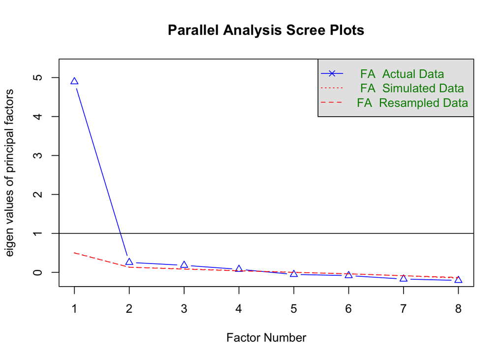

```
## Parallel analysis suggests that the number of factors =  4  and the number of components =  NA
```

```
## Factor Analysis using method =  minres
## Call: fa(r = d_pca_injunctivecontactnorms, nfactors = 4, rotate = "Varimax",
##     fm = "minres")
## Standardized loadings (pattern matrix) based upon correlation matrix
##                                    MR1  MR2  MR3  MR4   h2     u2 com
## sr_22a_expect_contact_parents     0.27 0.94 0.17 0.12 1.00 0.0044 1.3
## sr_22b_expect_contact_spouse      0.51 0.24 0.61 0.10 0.69 0.3074 2.3
## sr_22c_expect_contact_children    0.26 0.21 0.78 0.25 0.78 0.2175 1.6
## sr_22d_expect_contact_otherfamily 0.73 0.32 0.35 0.18 0.79 0.2124 2.0
## sr_22e_expect_contact_friends     0.88 0.29 0.23 0.19 0.94 0.0620 1.5
## sr_22f_expect_contact_coworkers   0.46 0.44 0.21 0.43 0.64 0.3619 3.4
## sr_22g_expect_contact_recpartners 0.69 0.27 0.28 0.38 0.77 0.2324 2.3
## sr_22h_expect_contact_faithcommun 0.38 0.22 0.39 0.62 0.73 0.2725 2.8
##
##                        MR1  MR2  MR3  MR4
## SS loadings           2.53 1.48 1.45 0.86
## Proportion Var        0.32 0.19 0.18 0.11
## Cumulative Var        0.32 0.50 0.68 0.79
## Proportion Explained  0.40 0.23 0.23 0.14
## Cumulative Proportion 0.40 0.63 0.86 1.00
##
## Mean item complexity =  2.1
## Test of the hypothesis that 4 factors are sufficient.
##
## The degrees of freedom for the null model are  28  and the objective function was  5.92 with Chi Square of  3023.99
## The degrees of freedom for the model are 2  and the objective function was  0.02
##
## The root mean square of the residuals (RMSR) is  0.01
## The df corrected root mean square of the residuals is  0.02
##
## The harmonic number of observations is  515 with the empirical chi square  1.08  with prob <  0.58
## The total number of observations was  515  with Likelihood Chi Square =  11.67  with prob <  0.0029
##
## Tucker Lewis Index of factoring reliability =  0.955
## RMSEA index =  0.097  and the 90 % confidence intervals are  0.048 0.154
## BIC =  -0.82
## Fit based upon off diagonal values = 1
## Measures of factor score adequacy
##                                                    MR1  MR2  MR3  MR4
## Correlation of (regression) scores with factors   0.94 0.99 0.85 0.75
## Multiple R square of scores with factors          0.89 0.99 0.73 0.56
## Minimum correlation of possible factor scores     0.78 0.97 0.45 0.12
```

```
##
## Loadings:
##                                   MR1   MR2   MR3   MR4
## sr_22a_expect_contact_parents           0.939
## sr_22b_expect_contact_spouse      0.507       0.609
## sr_22c_expect_contact_children                0.779
## sr_22d_expect_contact_otherfamily 0.728 0.323 0.348
## sr_22e_expect_contact_friends     0.875
## sr_22f_expect_contact_coworkers   0.465 0.442       0.428
## sr_22g_expect_contact_recpartners 0.690             0.378
## sr_22h_expect_contact_faithcommun 0.385       0.387 0.617
##
##                  MR1   MR2   MR3   MR4
## SS loadings    2.534 1.482 1.450 0.863
## Proportion Var 0.317 0.185 0.181 0.108
## Cumulative Var 0.317 0.502 0.683 0.791
```

```
##  sr_22a_expect_contact_parents sr_22b_expect_contact_spouse
##  Min.   :1.000                 Min.   :1.000
##  1st Qu.:1.000                 1st Qu.:1.000
##  Median :3.000                 Median :2.000
##  Mean   :2.794                 Mean   :2.656
##  3rd Qu.:5.000                 3rd Qu.:5.000
##  Max.   :5.000                 Max.   :5.000
##  sr_22c_expect_contact_children sr_22d_expect_contact_otherfamily
##  Min.   :1.000                  Min.   :1.000
##  1st Qu.:1.000                  1st Qu.:1.000
##  Median :3.000                  Median :2.000
##  Mean   :3.037                  Mean   :2.328
##  3rd Qu.:5.000                  3rd Qu.:4.000
##  Max.   :5.000                  Max.   :5.000
##  sr_22e_expect_contact_friends sr_22f_expect_contact_coworkers
##  Min.   :1.000                 Min.   :1.000
##  1st Qu.:1.000                 1st Qu.:1.000
##  Median :2.000                 Median :2.000
##  Mean   :2.311                 Mean   :2.703
##  3rd Qu.:3.000                 3rd Qu.:5.000
##  Max.   :5.000                 Max.   :5.000
##  sr_22g_expect_contact_recpartners sr_22h_expect_contact_faithcommun
##  Min.   :1.000                     Min.   :1.000
##  1st Qu.:1.000                     1st Qu.:1.000
##  Median :2.000                     Median :3.000
##  Mean   :2.445                     Mean   :2.911
##  3rd Qu.:4.000                     3rd Qu.:5.000
##  Max.   :5.000                     Max.   :5.000
```

```
##     sr_22a_expect_contact_parents      sr_22b_expect_contact_spouse
##                          1.758903                          1.711808
##    sr_22c_expect_contact_children sr_22d_expect_contact_otherfamily
##                          1.765591                          1.574074
##     sr_22e_expect_contact_friends   sr_22f_expect_contact_coworkers
##                          1.564621                          1.713727
## sr_22g_expect_contact_recpartners sr_22h_expect_contact_faithcommun
##                          1.623737                          1.753202
```

#### Injunctive Norms (contact) - 2nd factor (Spouse & Children) - Correlation

```
##
##  Spearman's rank correlation rho
##
## data:  OLR_complete_cases$sr_22b_expect_contact_spouse and OLR_complete_cases$sr_22c_expect_contact_children
## S = 7286428, p-value < 2.2e-16
## alternative hypothesis: true rho is not equal to 0
## sample estimates:
##       rho
## 0.6799293
```

Correlation test of the two descriptive norms items for Spouse and Children, showing moderate positive correlation. Spearman’s rho is 0.6799293 with a p-value of 3.944100610^{-71}.

#### Injunctive Norms (contact) - 3rd factor (Non-family) - Cronbach Alpha

```
##
## Reliability analysis
## Call: psych::alpha(x = d_pca_injunctivecontactnormsnonfamily, na.rm = TRUE,
##     use = "pairwise")
##
##   raw_alpha std.alpha G6(smc) average_r S/N    ase mean  sd median_r
##       0.91      0.92    0.91      0.69  11 0.0061  2.5 1.4     0.66
##
##  lower alpha upper     95% confidence boundaries
## 0.9 0.91 0.93
##
##  Reliability if an item is dropped:
##                                   raw_alpha std.alpha G6(smc) average_r  S/N
## sr_22d_expect_contact_otherfamily      0.89      0.89    0.87      0.67  8.2
## sr_22e_expect_contact_friends          0.88      0.88    0.86      0.65  7.5
## sr_22f_expect_contact_coworkers        0.91      0.91    0.90      0.71 10.0
## sr_22g_expect_contact_recpartners      0.88      0.89    0.87      0.66  7.8
## sr_22h_expect_contact_faithcommun      0.91      0.91    0.90      0.73 10.7
##                                   alpha se  var.r med.r
## sr_22d_expect_contact_otherfamily   0.0081 0.0053  0.66
## sr_22e_expect_contact_friends       0.0086 0.0033  0.64
## sr_22f_expect_contact_coworkers     0.0070 0.0112  0.71
## sr_22g_expect_contact_recpartners   0.0086 0.0092  0.62
## sr_22h_expect_contact_faithcommun   0.0065 0.0083  0.72
##
##  Item statistics
##                                     n raw.r std.r r.cor r.drop mean  sd
## sr_22d_expect_contact_otherfamily 515  0.88  0.88  0.86   0.81  2.3 1.6
## sr_22e_expect_contact_friends     515  0.90  0.91  0.90   0.85  2.3 1.6
## sr_22f_expect_contact_coworkers   515  0.83  0.83  0.75   0.73  2.7 1.7
## sr_22g_expect_contact_recpartners 515  0.90  0.90  0.88   0.84  2.4 1.6
## sr_22h_expect_contact_faithcommun 515  0.81  0.81  0.73   0.70  2.9 1.8
##
## Non missing response frequency for each item
##                                      1    2    3    4    5 miss
## sr_22d_expect_contact_otherfamily 0.50 0.11 0.13 0.07 0.19    0
## sr_22e_expect_contact_friends     0.50 0.13 0.13 0.06 0.19    0
## sr_22f_expect_contact_coworkers   0.42 0.10 0.12 0.06 0.30    0
## sr_22g_expect_contact_recpartners 0.47 0.13 0.13 0.06 0.22    0
## sr_22h_expect_contact_faithcommun 0.39 0.07 0.14 0.05 0.35    0
```

$$\\[.05in]$$

### Injunctive Norms (motivation)

*“How motivated are you to comply with the expectations of each of these people?”*

Two factor solution (70% cv)  
1. Multi-item composite variable (Fam): Parents, Spouse, Children  
2. Multi-item composite variable (Nonfam): Otherfam, Friends, Cowork, Recpartners, Faith

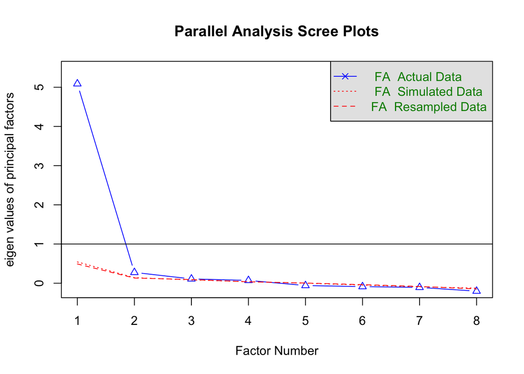

```
## Parallel analysis suggests that the number of factors =  2  and the number of components =  NA
```

```
## Factor Analysis using method =  minres
## Call: fa(r = d_pca_injunctivemotivation, nfactors = 2, rotate = "Varimax",
##     fm = "minres")
## Standardized loadings (pattern matrix) based upon correlation matrix
##                                         MR1  MR2   h2   u2 com
## sr_23a_motivated_to_comply_parents     0.49 0.48 0.47 0.53 2.0
## sr_23b_motivated_to_comply_spouse      0.35 0.88 0.90 0.10 1.3
## sr_23c_motivated_to_comply_children    0.44 0.66 0.63 0.37 1.7
## sr_23d_motivated_to_comply_otherfamily 0.77 0.43 0.77 0.23 1.6
## sr_23e_motivated_to_comply_friends     0.81 0.38 0.80 0.20 1.4
## sr_23f_motivated_to_comply_coworkers   0.74 0.35 0.67 0.33 1.4
## sr_23g_motivated_to_comply_recpartners 0.81 0.37 0.79 0.21 1.4
## sr_23h_motivated_to_comply_faithcommun 0.61 0.42 0.56 0.44 1.8
##
##                        MR1  MR2
## SS loadings           3.37 2.21
## Proportion Var        0.42 0.28
## Cumulative Var        0.42 0.70
## Proportion Explained  0.60 0.40
## Cumulative Proportion 0.60 1.00
##
## Mean item complexity =  1.6
## Test of the hypothesis that 2 factors are sufficient.
##
## The degrees of freedom for the null model are  28  and the objective function was  6.21 with Chi Square of  3169.46
## The degrees of freedom for the model are 13  and the objective function was  0.25
##
## The root mean square of the residuals (RMSR) is  0.03
## The df corrected root mean square of the residuals is  0.04
##
## The harmonic number of observations is  515 with the empirical chi square  25.58  with prob <  0.019
## The total number of observations was  515  with Likelihood Chi Square =  128.92  with prob <  3.4e-21
##
## Tucker Lewis Index of factoring reliability =  0.92
## RMSEA index =  0.132  and the 90 % confidence intervals are  0.112 0.153
## BIC =  47.74
## Fit based upon off diagonal values = 1
## Measures of factor score adequacy
##                                                    MR1  MR2
## Correlation of (regression) scores with factors   0.93 0.92
## Multiple R square of scores with factors          0.86 0.85
## Minimum correlation of possible factor scores     0.72 0.70
```

```
##
## Loadings:
##                                        MR1   MR2
## sr_23a_motivated_to_comply_parents     0.492 0.476
## sr_23b_motivated_to_comply_spouse      0.351 0.881
## sr_23c_motivated_to_comply_children    0.439 0.664
## sr_23d_motivated_to_comply_otherfamily 0.769 0.425
## sr_23e_motivated_to_comply_friends     0.807 0.380
## sr_23f_motivated_to_comply_coworkers   0.736 0.353
## sr_23g_motivated_to_comply_recpartners 0.806 0.369
## sr_23h_motivated_to_comply_faithcommun 0.615 0.423
##
##                  MR1   MR2
## SS loadings    3.371 2.210
## Proportion Var 0.421 0.276
## Cumulative Var 0.421 0.698
```

```
##  sr_23a_motivated_to_comply_parents sr_23b_motivated_to_comply_spouse
##  Min.   :1.000                      Min.   :1.000
##  1st Qu.:4.000                      1st Qu.:4.000
##  Median :4.000                      Median :4.000
##  Mean   :4.909                      Mean   :4.932
##  3rd Qu.:8.000                      3rd Qu.:8.000
##  Max.   :8.000                      Max.   :8.000
##  sr_23c_motivated_to_comply_children sr_23d_motivated_to_comply_otherfamily
##  Min.   :1.000                       Min.   :1.000
##  1st Qu.:4.000                       1st Qu.:3.000
##  Median :4.000                       Median :4.000
##  Mean   :5.243                       Mean   :4.206
##  3rd Qu.:8.000                       3rd Qu.:4.000
##  Max.   :8.000                       Max.   :8.000
##  sr_23e_motivated_to_comply_friends sr_23f_motivated_to_comply_coworkers
##  Min.   :1.000                      Min.   :1.000
##  1st Qu.:3.000                      1st Qu.:3.000
##  Median :4.000                      Median :4.000
##  Mean   :4.179                      Mean   :4.619
##  3rd Qu.:4.000                      3rd Qu.:8.000
##  Max.   :8.000                      Max.   :8.000
##  sr_23g_motivated_to_comply_recpartners sr_23h_motivated_to_comply_faithcommun
##  Min.   :1.000                          Min.   :1.000
##  1st Qu.:3.000                          1st Qu.:4.000
##  Median :4.000                          Median :4.000
##  Mean   :4.359                          Mean   :4.957
##  3rd Qu.:7.000                          3rd Qu.:8.000
##  Max.   :8.000                          Max.   :8.000
```

```
##     sr_23a_motivated_to_comply_parents      sr_23b_motivated_to_comply_spouse
##                               2.572948                               2.495374
##    sr_23c_motivated_to_comply_children sr_23d_motivated_to_comply_otherfamily
##                               2.577461                               2.320683
##     sr_23e_motivated_to_comply_friends   sr_23f_motivated_to_comply_coworkers
##                               2.228907                               2.522045
## sr_23g_motivated_to_comply_recpartners sr_23h_motivated_to_comply_faithcommun
##                               2.400771                               2.589661
```

#### Injunctive Norms (motivation) - 1st factor (Immediate Family) - Cronbach Alpha

```
##
## Reliability analysis
## Call: psych::alpha(x = d_pca_injunctivemotivationfamily, na.rm = TRUE,
##     use = "pairwise")
##
##   raw_alpha std.alpha G6(smc) average_r S/N   ase mean  sd median_r
##       0.83      0.83    0.78      0.62 4.9 0.013    5 2.2     0.61
##
##  lower alpha upper     95% confidence boundaries
## 0.8 0.83 0.85
##
##  Reliability if an item is dropped:
##                                     raw_alpha std.alpha G6(smc) average_r S/N
## sr_23a_motivated_to_comply_parents       0.85      0.85    0.74      0.74 5.6
## sr_23b_motivated_to_comply_spouse        0.67      0.67    0.51      0.51 2.1
## sr_23c_motivated_to_comply_children      0.76      0.76    0.61      0.61 3.1
##                                     alpha se var.r med.r
## sr_23a_motivated_to_comply_parents     0.013    NA  0.74
## sr_23b_motivated_to_comply_spouse      0.029    NA  0.51
## sr_23c_motivated_to_comply_children    0.021    NA  0.61
##
##  Item statistics
##                                       n raw.r std.r r.cor r.drop mean  sd
## sr_23a_motivated_to_comply_parents  515  0.82  0.82  0.65   0.60  4.9 2.6
## sr_23b_motivated_to_comply_spouse   515  0.90  0.91  0.86   0.78  4.9 2.5
## sr_23c_motivated_to_comply_children 515  0.87  0.87  0.78   0.69  5.2 2.6
##
## Non missing response frequency for each item
##                                        1    3    4    7    8 miss
## sr_23a_motivated_to_comply_parents  0.18 0.05 0.36 0.10 0.30    0
## sr_23b_motivated_to_comply_spouse   0.17 0.05 0.37 0.14 0.27    0
## sr_23c_motivated_to_comply_children 0.15 0.05 0.34 0.08 0.37    0
```

#### Injunctive Norms (motivation) - 2nd factor (Non-family) - Cronbach Alpha

```
##
## Reliability analysis
## Call: psych::alpha(x = d_pca_injunctivemotivationnonfamily, na.rm = TRUE,
##     use = "pairwise")
##
##   raw_alpha std.alpha G6(smc) average_r S/N    ase mean  sd median_r
##       0.92      0.92    0.91      0.71  12 0.0056  4.5 2.1      0.7
##
##  lower alpha upper     95% confidence boundaries
## 0.91 0.92 0.93
##
##  Reliability if an item is dropped:
##                                        raw_alpha std.alpha G6(smc) average_r
## sr_23d_motivated_to_comply_otherfamily      0.90      0.90    0.88      0.69
## sr_23e_motivated_to_comply_friends          0.90      0.90    0.87      0.69
## sr_23f_motivated_to_comply_coworkers        0.91      0.91    0.90      0.72
## sr_23g_motivated_to_comply_recpartners      0.89      0.90    0.88      0.68
## sr_23h_motivated_to_comply_faithcommun      0.92      0.92    0.91      0.75
##                                         S/N alpha se  var.r med.r
## sr_23d_motivated_to_comply_otherfamily  9.1   0.0074 0.0043  0.70
## sr_23e_motivated_to_comply_friends      8.7   0.0076 0.0032  0.69
## sr_23f_motivated_to_comply_coworkers   10.3   0.0068 0.0094  0.73
## sr_23g_motivated_to_comply_recpartners  8.6   0.0079 0.0074  0.66
## sr_23h_motivated_to_comply_faithcommun 12.2   0.0057 0.0034  0.74
##
##  Item statistics
##                                          n raw.r std.r r.cor r.drop mean  sd
## sr_23d_motivated_to_comply_otherfamily 515  0.89  0.89  0.87   0.82  4.2 2.3
## sr_23e_motivated_to_comply_friends     515  0.90  0.90  0.89   0.84  4.2 2.2
## sr_23f_motivated_to_comply_coworkers   515  0.86  0.86  0.80   0.77  4.6 2.5
## sr_23g_motivated_to_comply_recpartners 515  0.91  0.91  0.89   0.85  4.4 2.4
## sr_23h_motivated_to_comply_faithcommun 515  0.82  0.81  0.74   0.71  5.0 2.6
##
## Non missing response frequency for each item
##                                           1    3    4    7    8 miss
## sr_23d_motivated_to_comply_otherfamily 0.21 0.08 0.46 0.08 0.17    0
## sr_23e_motivated_to_comply_friends     0.20 0.06 0.51 0.07 0.16    0
## sr_23f_motivated_to_comply_coworkers   0.19 0.07 0.40 0.05 0.28    0
## sr_23g_motivated_to_comply_recpartners 0.20 0.08 0.44 0.07 0.21    0
## sr_23h_motivated_to_comply_faithcommun 0.18 0.05 0.36 0.08 0.33    0
```

$$\\[.05in]$$

### CIM - Benefits

*“How often do you hear ____ talk about the importance of reducing climate change?”*  
*[your friends, family, and coworkers]*  
*[public figures whom you respect]*  
*[about the importance of reducing climate change in the media? (TV, movies, radio, newspapers/news websites, magazines, etc.)]*

One-factor solution:  
1. Multi-item composite variable: F/Fam/Cowork, Public Figures, Media

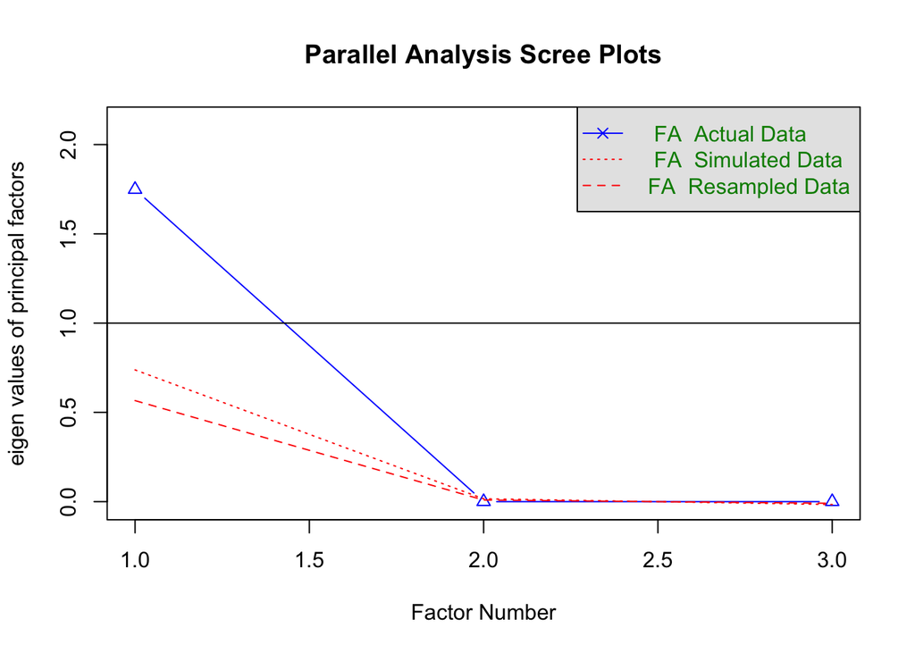

```
## Parallel analysis suggests that the number of factors =  1  and the number of components =  NA
```

```
## Factor Analysis using method =  minres
## Call: fa(r = d_pca_CIMbenefits, nfactors = 2, rotate = "Varimax", fm = "minres")
## Standardized loadings (pattern matrix) based upon correlation matrix
##                              MR1  MR2   h2   u2 com
## sr_16_hear_friends_talk     0.55 0.35 0.43 0.57 1.7
## sr_17_hear_media            0.74 0.10 0.56 0.44 1.0
## sr_18_hear_public_officials 0.84 0.31 0.81 0.19 1.3
##
##                        MR1  MR2
## SS loadings           1.57 0.23
## Proportion Var        0.52 0.08
## Cumulative Var        0.52 0.60
## Proportion Explained  0.87 0.13
## Cumulative Proportion 0.87 1.00
##
## Mean item complexity =  1.3
## Test of the hypothesis that 2 factors are sufficient.
##
## The degrees of freedom for the null model are  3  and the objective function was  0.98 with Chi Square of  502.59
## The degrees of freedom for the model are -2  and the objective function was  0
##
## The root mean square of the residuals (RMSR) is  0
## The df corrected root mean square of the residuals is  NA
##
## The harmonic number of observations is  515 with the empirical chi square  0  with prob <  NA
## The total number of observations was  515  with Likelihood Chi Square =  0  with prob <  NA
##
## Tucker Lewis Index of factoring reliability =  1.006
## Fit based upon off diagonal values = 1
## Measures of factor score adequacy
##                                                    MR1   MR2
## Correlation of (regression) scores with factors   0.88  0.41
## Multiple R square of scores with factors          0.78  0.17
## Minimum correlation of possible factor scores     0.55 -0.67
```

```
##
## Loadings:
##                             MR1   MR2
## sr_16_hear_friends_talk     0.554 0.350
## sr_17_hear_media            0.743
## sr_18_hear_public_officials 0.843 0.309
##
##                  MR1   MR2
## SS loadings    1.571 0.228
## Proportion Var 0.524 0.076
## Cumulative Var 0.524 0.600
```

#### CIM - Benefits - Cronbach Alpha

```
##
## Reliability analysis
## Call: psych::alpha(x = d_pca_CIMbenefits, na.rm = TRUE, use = "pairwise")
##
##   raw_alpha std.alpha G6(smc) average_r S/N   ase mean  sd median_r
##       0.79      0.79    0.73      0.56 3.8 0.016  2.3 1.1     0.58
##
##  lower alpha upper     95% confidence boundaries
## 0.76 0.79 0.82
##
##  Reliability if an item is dropped:
##                             raw_alpha std.alpha G6(smc) average_r S/N alpha se
## sr_16_hear_friends_talk          0.79      0.79    0.66      0.66 3.8    0.018
## sr_17_hear_media                 0.73      0.73    0.58      0.58 2.7    0.024
## sr_18_hear_public_officials      0.61      0.62    0.45      0.45 1.6    0.034
##                             var.r med.r
## sr_16_hear_friends_talk        NA  0.66
## sr_17_hear_media               NA  0.58
## sr_18_hear_public_officials    NA  0.45
##
##  Item statistics
##                               n raw.r std.r r.cor r.drop mean  sd
## sr_16_hear_friends_talk     515  0.78  0.80  0.63   0.56  1.9 1.2
## sr_17_hear_media            515  0.85  0.83  0.71   0.63  2.7 1.4
## sr_18_hear_public_officials 515  0.88  0.89  0.82   0.73  2.2 1.3
##
## Non missing response frequency for each item
##                                1    2    3    4    5 miss
## sr_16_hear_friends_talk     0.53 0.22 0.13 0.09 0.04    0
## sr_17_hear_media            0.26 0.24 0.15 0.21 0.15    0
## sr_18_hear_public_officials 0.39 0.26 0.14 0.16 0.05    0
```

$$\\[.05in]$$

### CIM - Perceived Risk

*“How important is each of the following issues to you today?”*  
*“How important is the issue of climate change to you personally?”*  
*“How worried are you about climate change?”*  
*“How much do you think climate change will harm you personally?”*  
*“How much do you think climate change will harm future generations of people?”*

NOTE - removing #7 for now until I understand how to properly account for it as a categorical var.

Three-factor solution  
1. Multi-item composite variable: CC importance as an issue, CC personal importance, CC worry, belief of personal harm from CC  
2. REMOVED FOR NOW: 1-item variable: anthropocentric CC belief 3. 1-item variable: belief of harm to future generations from CC

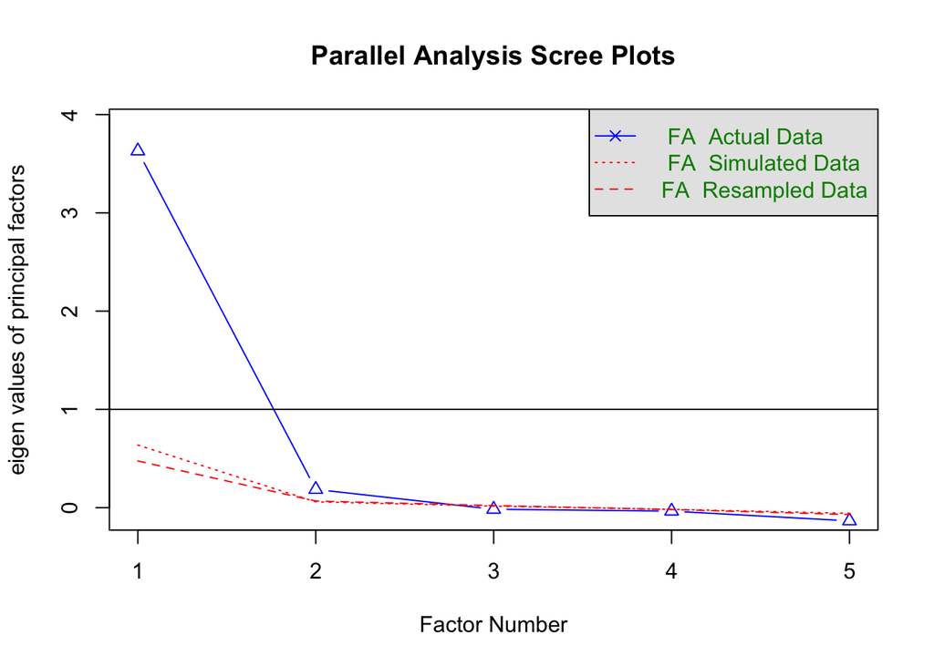

```
## Parallel analysis suggests that the number of factors =  2  and the number of components =  NA
```

```
## Factor Analysis using method =  minres
## Call: fa(r = d_pca_CIMperceivedrisk, nfactors = 2, rotate = "Varimax",
##     fm = "minres")
## Standardized loadings (pattern matrix) based upon correlation matrix
##                                 MR1  MR2   h2     u2 com
## sr_3b_importance_climatechange 0.74 0.42 0.73 0.2735 1.6
## sr_8_importance_personally     0.86 0.42 0.92 0.0840 1.4
## sr_9_worried                   0.79 0.43 0.81 0.1882 1.5
## sr_10_harm_you_personally      0.48 0.62 0.62 0.3827 1.9
## sr_11_harm_future_generations  0.38 0.92 1.00 0.0031 1.3
##
##                        MR1  MR2
## SS loadings           2.30 1.77
## Proportion Var        0.46 0.35
## Cumulative Var        0.46 0.81
## Proportion Explained  0.57 0.43
## Cumulative Proportion 0.57 1.00
##
## Mean item complexity =  1.6
## Test of the hypothesis that 2 factors are sufficient.
##
## The degrees of freedom for the null model are  10  and the objective function was  4.26 with Chi Square of  2178.37
## The degrees of freedom for the model are 1  and the objective function was  0.02
##
## The root mean square of the residuals (RMSR) is  0.01
## The df corrected root mean square of the residuals is  0.03
##
## The harmonic number of observations is  515 with the empirical chi square  1.01  with prob <  0.32
## The total number of observations was  515  with Likelihood Chi Square =  10.59  with prob <  0.0011
##
## Tucker Lewis Index of factoring reliability =  0.956
## RMSEA index =  0.136  and the 90 % confidence intervals are  0.071 0.216
## BIC =  4.35
## Fit based upon off diagonal values = 1
## Measures of factor score adequacy
##                                                    MR1  MR2
## Correlation of (regression) scores with factors   0.95 0.99
## Multiple R square of scores with factors          0.90 0.97
## Minimum correlation of possible factor scores     0.79 0.95
```

```
##
## Loadings:
##                                MR1   MR2
## sr_3b_importance_climatechange 0.740 0.424
## sr_8_importance_personally     0.862 0.416
## sr_9_worried                   0.794 0.426
## sr_10_harm_you_personally      0.483 0.620
## sr_11_harm_future_generations  0.384 0.921
##
##                  MR1   MR2
## SS loadings    2.301 1.767
## Proportion Var 0.460 0.353
## Cumulative Var 0.460 0.814
```

#### CIM - Perceived Risk - 1st factor (Personal) - Cronbach Alpha

```
##
## Reliability analysis
## Call: psych::alpha(x = d_pca_CIMperceivedriskpersonal, na.rm = TRUE,
##     use = "pairwise")
##
##   raw_alpha std.alpha G6(smc) average_r S/N    ase mean  sd median_r
##       0.91      0.92     0.9      0.73  11 0.0063  2.7 1.1     0.73
##
##  lower alpha upper     95% confidence boundaries
## 0.9 0.91 0.92
##
##  Reliability if an item is dropped:
##                                raw_alpha std.alpha G6(smc) average_r  S/N
## sr_3b_importance_climatechange      0.89      0.89    0.86      0.73  8.2
## sr_8_importance_personally          0.85      0.86    0.82      0.67  6.2
## sr_9_worried                        0.87      0.88    0.84      0.70  7.0
## sr_10_harm_you_personally           0.92      0.93    0.90      0.81 13.2
##                                alpha se  var.r med.r
## sr_3b_importance_climatechange   0.0086 0.0119  0.69
## sr_8_importance_personally       0.0112 0.0082  0.65
## sr_9_worried                     0.0095 0.0117  0.69
## sr_10_harm_you_personally        0.0057 0.0016  0.81
##
##  Item statistics
##                                  n raw.r std.r r.cor r.drop mean  sd
## sr_3b_importance_climatechange 515  0.90  0.89  0.85   0.80  2.7 1.4
## sr_8_importance_personally     515  0.94  0.94  0.93   0.89  2.9 1.3
## sr_9_worried                   515  0.91  0.92  0.89   0.85  2.3 1.0
## sr_10_harm_you_personally      515  0.82  0.82  0.72   0.69  2.9 1.2
##
## Non missing response frequency for each item
##                                   1    2    3    4    5 miss
## sr_3b_importance_climatechange 0.27 0.19 0.25 0.11 0.18    0
## sr_8_importance_personally     0.19 0.18 0.32 0.17 0.14    0
## sr_9_worried                   0.25 0.38 0.20 0.16 0.00    0
## sr_10_harm_you_personally      0.13 0.26 0.30 0.20 0.11    0
```

$$\\[.05in]$$

### Efficacy

*“Below is a list of actions that individuals could take to reduce climate change. If YOU took these actions, how effective would each be for reducing climate change?”*  
*“Below are some public and private organizations who make decisions that have an impact on climate change. In general, how COMPETENT is each in addressing climate change?”*  
*“In general, how RESPONSIVE is each in addressing climate change?”*  
*“How much do you agree that each type of organization is generally IN A POSITION TO EFFECTIVELY reduce climate change?”*

Three-factor solution:  
1. 1-item variable: 21a: Is contacting elected reps an effective action?  
2. Multi-item composite variable: All types (fed, state, business, ngo) are in a position to effect change  
3. Multi-item composite variable: The competency and responsiveness of fed, state, and business  
4. 2-item composite variable: The competency and responsiveness of ngo only

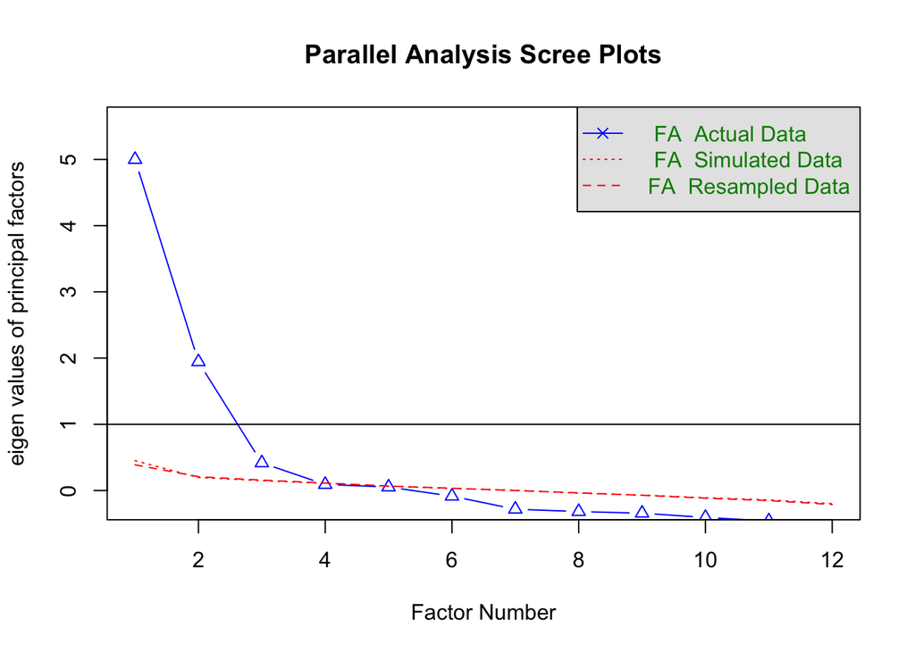

```
## Parallel analysis suggests that the number of factors =  3  and the number of components =  NA
```

```
## Factor Analysis using method =  minres
## Call: fa(r = d_pca_efficacygroup, nfactors = 3, rotate = "Varimax",
##     fm = "minres")
## Standardized loadings (pattern matrix) based upon correlation matrix
##                              MR1   MR2  MR3   h2   u2 com
## sr_27a_competent_fed        0.03  0.84 0.08 0.72 0.28 1.0
## sr_27b_competent_state      0.31  0.56 0.36 0.54 0.46 2.3
## sr_27c_competent_business   0.20  0.51 0.54 0.59 0.41 2.3
## sr_27d_competent_ngo        0.41  0.17 0.63 0.59 0.41 1.9
## sr_28a_responsive_fed      -0.05  0.81 0.15 0.69 0.31 1.1
## sr_28b_responsive_state     0.18  0.63 0.41 0.60 0.40 1.9
## sr_28c_responsive_business  0.16  0.51 0.61 0.67 0.33 2.1
## sr_28d_responsive_ngo       0.28  0.18 0.75 0.68 0.32 1.4
## sr_29a_effective_fed        0.87  0.14 0.03 0.77 0.23 1.1
## sr_29b_effective_state      0.93  0.10 0.12 0.90 0.10 1.1
## sr_29c_effective_business   0.86 -0.02 0.25 0.80 0.20 1.2
## sr_29d_effective_ngo        0.79 -0.02 0.31 0.71 0.29 1.3
##
##                        MR1  MR2  MR3
## SS loadings           3.42 2.70 2.13
## Proportion Var        0.28 0.23 0.18
## Cumulative Var        0.28 0.51 0.69
## Proportion Explained  0.41 0.33 0.26
## Cumulative Proportion 0.41 0.74 1.00
##
## Mean item complexity =  1.5
## Test of the hypothesis that 3 factors are sufficient.
##
## The degrees of freedom for the null model are  66  and the objective function was  9.5 with Chi Square of  4839.6
## The degrees of freedom for the model are 33  and the objective function was  1.39
##
## The root mean square of the residuals (RMSR) is  0.05
## The df corrected root mean square of the residuals is  0.07
##
## The harmonic number of observations is  515 with the empirical chi square  147.35  with prob <  2.2e-16
## The total number of observations was  515  with Likelihood Chi Square =  707.15  with prob <  1.8e-127
##
## Tucker Lewis Index of factoring reliability =  0.716
## RMSEA index =  0.199  and the 90 % confidence intervals are  0.187 0.212
## BIC =  501.09
## Fit based upon off diagonal values = 0.99
## Measures of factor score adequacy
##                                                    MR1  MR2  MR3
## Correlation of (regression) scores with factors   0.97 0.92 0.88
## Multiple R square of scores with factors          0.94 0.85 0.77
## Minimum correlation of possible factor scores     0.87 0.70 0.54
```

```
##
## Loadings:
##                            MR1    MR2    MR3
## sr_27a_competent_fed               0.843
## sr_27b_competent_state      0.310  0.564  0.358
## sr_27c_competent_business          0.510  0.541
## sr_27d_competent_ngo        0.407         0.630
## sr_28a_responsive_fed              0.814
## sr_28b_responsive_state            0.630  0.411
## sr_28c_responsive_business         0.515  0.613
## sr_28d_responsive_ngo                     0.752
## sr_29a_effective_fed        0.866
## sr_29b_effective_state      0.933
## sr_29c_effective_business   0.856
## sr_29d_effective_ngo        0.788         0.305
##
##                  MR1   MR2   MR3
## SS loadings    3.416 2.702 2.132
## Proportion Var 0.285 0.225 0.178
## Cumulative Var 0.285 0.510 0.687
```

#### Efficacy - 1st variable (is contacting elected officials an effective action?)

```
## [1] 2.584466
```

```
## [1] 1.055904
```

#### Efficacy - 2nd Factor (All types’ ability to effect change) - Cronbach Alpha

```
##
## Reliability analysis
## Call: psych::alpha(x = d_pca_efficacyeffectchangesecond, na.rm = TRUE,
##     use = "pairwise")
##
##   raw_alpha std.alpha G6(smc) average_r S/N    ase mean  sd median_r
##       0.93      0.93    0.92      0.77  13 0.0051  3.3 1.1     0.78
##
##  lower alpha upper     95% confidence boundaries
## 0.92 0.93 0.94
##
##  Reliability if an item is dropped:
##                           raw_alpha std.alpha G6(smc) average_r  S/N alpha se
## sr_29a_effective_fed           0.92      0.92    0.88      0.79 11.1   0.0063
## sr_29b_effective_state         0.89      0.89    0.86      0.74  8.5   0.0083
## sr_29c_effective_business      0.90      0.90    0.88      0.76  9.4   0.0075
## sr_29d_effective_ngo           0.92      0.92    0.89      0.80 12.2   0.0059
##                             var.r med.r
## sr_29a_effective_fed      0.00048  0.80
## sr_29b_effective_state    0.00459  0.76
## sr_29c_effective_business 0.00844  0.76
## sr_29d_effective_ngo      0.00207  0.80
##
##  Item statistics
##                             n raw.r std.r r.cor r.drop mean  sd
## sr_29a_effective_fed      515  0.90  0.90  0.86   0.82  3.3 1.3
## sr_29b_effective_state    515  0.94  0.94  0.92   0.89  3.3 1.2
## sr_29c_effective_business 515  0.92  0.92  0.89   0.86  3.4 1.2
## sr_29d_effective_ngo      515  0.88  0.88  0.83   0.79  3.2 1.1
##
## Non missing response frequency for each item
##                              1    2    3    4    5 miss
## sr_29a_effective_fed      0.14 0.07 0.33 0.24 0.22    0
## sr_29b_effective_state    0.11 0.08 0.37 0.26 0.18    0
## sr_29c_effective_business 0.11 0.06 0.38 0.26 0.19    0
## sr_29d_effective_ngo      0.12 0.07 0.42 0.27 0.13    0
```

#### Efficacy - 3rd Factor (Competency & Responsiveness of Fed, State, and Business) - Cronbach Alpha

```
##
## Reliability analysis
## Call: psych::alpha(x = d_pca_efficacycompetencyresponsivesecond, na.rm = TRUE,
##     use = "pairwise")
##
##   raw_alpha std.alpha G6(smc) average_r S/N    ase mean   sd median_r
##       0.88      0.88    0.91      0.55 7.4 0.0084  2.7 0.84     0.52
##
##  lower alpha upper     95% confidence boundaries
## 0.86 0.88 0.9
##
##  Reliability if an item is dropped:
##                            raw_alpha std.alpha G6(smc) average_r S/N alpha se
## sr_27a_competent_fed            0.86      0.86    0.87      0.56 6.3   0.0100
## sr_27b_competent_state          0.86      0.86    0.87      0.56 6.4   0.0097
## sr_27c_competent_business       0.86      0.86    0.89      0.56 6.2   0.0099
## sr_28a_responsive_fed           0.86      0.86    0.87      0.56 6.3   0.0098
## sr_28b_responsive_state         0.85      0.85    0.86      0.54 5.8   0.0105
## sr_28c_responsive_business      0.86      0.86    0.89      0.55 6.1   0.0101
##                             var.r med.r
## sr_27a_competent_fed       0.0121  0.56
## sr_27b_competent_state     0.0116  0.52
## sr_27c_competent_business  0.0147  0.53
## sr_28a_responsive_fed      0.0091  0.52
## sr_28b_responsive_state    0.0131  0.52
## sr_28c_responsive_business 0.0142  0.52
##
##  Item statistics
##                              n raw.r std.r r.cor r.drop mean  sd
## sr_27a_competent_fed       515  0.80  0.78  0.75   0.69  2.5 1.1
## sr_27b_competent_state     515  0.77  0.78  0.75   0.66  2.8 1.0
## sr_27c_competent_business  515  0.78  0.79  0.73   0.68  2.9 1.0
## sr_28a_responsive_fed      515  0.79  0.78  0.75   0.68  2.5 1.2
## sr_28b_responsive_state    515  0.82  0.82  0.81   0.73  2.8 1.0
## sr_28c_responsive_business 515  0.79  0.80  0.75   0.70  2.8 1.0
##
## Non missing response frequency for each item
##                               1    2    3    4    5 miss
## sr_27a_competent_fed       0.27 0.20 0.36 0.13 0.04    0
## sr_27b_competent_state     0.14 0.19 0.44 0.19 0.04    0
## sr_27c_competent_business  0.13 0.16 0.48 0.19 0.04    0
## sr_28a_responsive_fed      0.29 0.16 0.38 0.13 0.04    0
## sr_28b_responsive_state    0.13 0.20 0.43 0.20 0.04    0
## sr_28c_responsive_business 0.13 0.17 0.47 0.19 0.04    0
```

#### Efficacy - 4th Factor (Competency & Responsiveness of NGO) - Correlation

```
##
##  Spearman's rank correlation rho
##
## data:  OLR_complete_cases$sr_27d_competent_ngo and OLR_complete_cases$sr_28d_responsive_ngo
## S = 8184977, p-value < 2.2e-16
## alternative hypothesis: true rho is not equal to 0
## sample estimates:
##       rho
## 0.6404588
```

```
## [1] 3.023301
```

```
## [1] 1.003613
```

```
## [1] 3.069903
```

```
## [1] 0.9738642
```

Correlation test of the competency and responsiveness scores for NGOs shows moderate positive correlation. Spearman’s rho is 0.6404588 with a p-value of 8.455005510^{-61}.

$$\\[.05in]$$

### TPB Behavioral Attitude

*“For me, contacting (writing letters, emailing, phoning my elected representatives in Congress to urge action on climate change on a regular basis during the next year would be …”*

Three-factor solution:  
1. 2-item variable: admirable/shameful, good/bad  
2. Multi-item composite variable: useful/useless, pleasant/intimidating, sensible/foolish  
3. Multi-item composite variable: cool/uncool, easy/awkward, exciting/boring

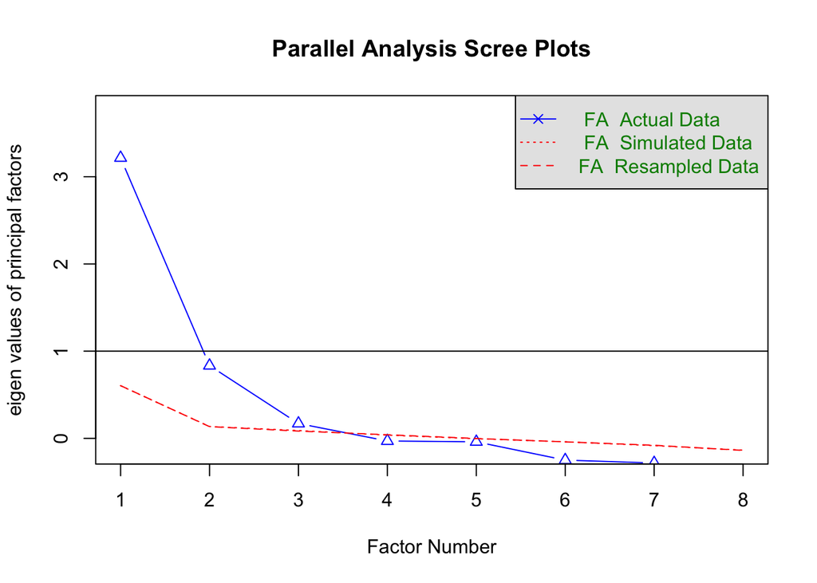

```
## Parallel analysis suggests that the number of factors =  3  and the number of components =  NA
```

```
## Factor Analysis using method =  minres
## Call: fa(r = ba2, nfactors = 3, rotate = "Varimax", fm = "minres")
## Standardized loadings (pattern matrix) based upon correlation matrix
##                                   MR1  MR2  MR3   h2    u2 com
## sr_32_contact_useful             0.08 0.86 0.13 0.77 0.233 1.1
## sr_33_contact_pleasant           0.10 0.62 0.20 0.43 0.568 1.3
## sr_34_contact_cool_reversed      0.47 0.19 0.56 0.56 0.441 2.2
## sr_35_contact_easy_reversed      0.35 0.18 0.70 0.65 0.354 1.6
## sr_36_contact_exciting_reversed  0.31 0.24 0.64 0.56 0.440 1.8
## sr_37_contact_sensible           0.16 0.64 0.18 0.47 0.530 1.3
## sr_38_contact_admirable_reversed 0.69 0.10 0.38 0.62 0.376 1.6
## sr_39_contact_good_reversed      0.96 0.08 0.18 0.96 0.042 1.1
##
##                        MR1  MR2  MR3
## SS loadings           1.87 1.68 1.46
## Proportion Var        0.23 0.21 0.18
## Cumulative Var        0.23 0.44 0.63
## Proportion Explained  0.37 0.34 0.29
## Cumulative Proportion 0.37 0.71 1.00
##
## Mean item complexity =  1.5
## Test of the hypothesis that 3 factors are sufficient.
##
## The degrees of freedom for the null model are  28  and the objective function was  3.38 with Chi Square of  1727.53
## The degrees of freedom for the model are 7  and the objective function was  0.05
##
## The root mean square of the residuals (RMSR) is  0.02
## The df corrected root mean square of the residuals is  0.04
##
## The harmonic number of observations is  515 with the empirical chi square  11.01  with prob <  0.14
## The total number of observations was  515  with Likelihood Chi Square =  27.11  with prob <  0.00032
##
## Tucker Lewis Index of factoring reliability =  0.952
## RMSEA index =  0.075  and the 90 % confidence intervals are  0.046 0.105
## BIC =  -16.6
## Fit based upon off diagonal values = 1
## Measures of factor score adequacy
##                                                    MR1  MR2  MR3
## Correlation of (regression) scores with factors   0.97 0.90 0.83
## Multiple R square of scores with factors          0.94 0.81 0.69
## Minimum correlation of possible factor scores     0.88 0.61 0.38
```

```
##
## Loadings:
##                                  MR1   MR2   MR3
## sr_32_contact_useful                   0.863
## sr_33_contact_pleasant                 0.618
## sr_34_contact_cool_reversed      0.465       0.555
## sr_35_contact_easy_reversed      0.352       0.700
## sr_36_contact_exciting_reversed  0.312       0.635
## sr_37_contact_sensible                 0.643
## sr_38_contact_admirable_reversed 0.687       0.376
## sr_39_contact_good_reversed      0.959
##
##                  MR1   MR2   MR3
## SS loadings    1.871 1.682 1.461
## Proportion Var 0.234 0.210 0.183
## Cumulative Var 0.234 0.444 0.627
```

#### TPB Behavioral Attitude - 1st factor - Correlation

```
##
##  Spearman's rank correlation rho
##
## data:  OLR_complete_cases$sr_38_contact_admirable and OLR_complete_cases$sr_39_contact_good
## S = 3911292, p-value < 2.2e-16
## alternative hypothesis: true rho is not equal to 0
## sample estimates:
##       rho
## 0.8281888
```

#### TPB Behavioral Attitude - 2nd factor - Cronbach Alpha

```
##
## Reliability analysis
## Call: psych::alpha(x = d_pca_behavioralattitude2, na.rm = TRUE, use = "pairwise")
##
##   raw_alpha std.alpha G6(smc) average_r S/N   ase mean  sd median_r
##       0.77      0.78    0.71      0.54 3.5 0.017  2.4 1.4     0.57
##
##  lower alpha upper     95% confidence boundaries
## 0.74 0.77 0.81
##
##  Reliability if an item is dropped:
##                        raw_alpha std.alpha G6(smc) average_r S/N alpha se var.r
## sr_32_contact_useful        0.62      0.62    0.45      0.45 1.6    0.033    NA
## sr_33_contact_pleasant      0.74      0.74    0.59      0.59 2.8    0.023    NA
## sr_37_contact_sensible      0.73      0.73    0.57      0.57 2.7    0.024    NA
##                        med.r
## sr_32_contact_useful    0.45
## sr_33_contact_pleasant  0.59
## sr_37_contact_sensible  0.57
##
##  Item statistics
##                          n raw.r std.r r.cor r.drop mean  sd
## sr_32_contact_useful   515  0.86  0.87  0.77   0.68  2.0 1.7
## sr_33_contact_pleasant 515  0.80  0.81  0.65   0.57  2.5 1.6
## sr_37_contact_sensible 515  0.83  0.82  0.67   0.59  2.8 1.7
##
## Non missing response frequency for each item
##                           0    1    2    3    4    5    6 miss
## sr_32_contact_useful   0.23 0.23 0.11 0.25 0.09 0.06 0.03    0
## sr_33_contact_pleasant 0.15 0.17 0.11 0.35 0.13 0.06 0.03    0
## sr_37_contact_sensible 0.15 0.12 0.11 0.28 0.17 0.11 0.06    0
```

#### TPB Behavioral Attitude - 3rd factor - Cronbach Alpha

```
##
## Reliability analysis
## Call: psych::alpha(x = d_pca_behavioralattitude3, na.rm = TRUE, use = "pairwise")
##
##   raw_alpha std.alpha G6(smc) average_r S/N   ase mean  sd median_r
##        0.8       0.8    0.73      0.58 4.1 0.015  3.3 1.5     0.58
##
##  lower alpha upper     95% confidence boundaries
## 0.77 0.8 0.83
##
##  Reliability if an item is dropped:
##                                 raw_alpha std.alpha G6(smc) average_r S/N
## sr_34_contact_cool_reversed          0.75      0.75    0.60      0.60 3.0
## sr_35_contact_easy_reversed          0.71      0.71    0.55      0.55 2.4
## sr_36_contact_exciting_reversed      0.73      0.73    0.58      0.58 2.7
##                                 alpha se var.r med.r
## sr_34_contact_cool_reversed        0.022    NA  0.60
## sr_35_contact_easy_reversed        0.026    NA  0.55
## sr_36_contact_exciting_reversed    0.024    NA  0.58
##
##  Item statistics
##                                   n raw.r std.r r.cor r.drop mean  sd
## sr_34_contact_cool_reversed     515  0.84  0.84  0.70   0.63  3.4 1.8
## sr_35_contact_easy_reversed     515  0.87  0.86  0.75   0.67  3.2 1.9
## sr_36_contact_exciting_reversed 515  0.83  0.85  0.72   0.65  3.2 1.6
##
## Non missing response frequency for each item
##                                    0    1    2    3    4    5    6 miss
## sr_34_contact_cool_reversed     0.08 0.11 0.10 0.11 0.33 0.13 0.14    0
## sr_35_contact_easy_reversed     0.10 0.12 0.13 0.14 0.26 0.10 0.15    0
## sr_36_contact_exciting_reversed 0.05 0.16 0.13 0.17 0.31 0.09 0.10    0
```

$$\\[.05in]$$
#### Perceived Behavioral Control - correlation

```
## [1] 3.075728
```

```
## [1] 1.830378
```

```
##
##  Spearman's rank correlation rho
##
## data:  OLR_complete_cases$sr_30_easy_to_call and OLR_complete_cases$sr_31_able_to_call
## S = 8443684, p-value < 2.2e-16
## alternative hypothesis: true rho is not equal to 0
## sample estimates:
##       rho
## 0.6290946
```

The two measures of perceived behavioral control show a moderate positive relationship, just barely under the .65 rule of thumb. Spearman’s rho is 0.6290946 with a p-value of 4.235488110^{-58}. This is not a strong enough correlation to justify a composite variable of the two items, so they will stay separate.

$$\\[.05in]$$

### Worldviews

We decided these will be kept as-is.

```
##  sr_41a_right_to_modify sr_41b_laws_of_nature sr_41c_ingenuity sr_41d_impotent
##  Min.   :1.000          Min.   :1.000         Min.   :1.00     Min.   :1.000
##  1st Qu.:2.000          1st Qu.:3.000         1st Qu.:3.00     1st Qu.:2.000
##  Median :3.000          Median :4.000         Median :3.00     Median :3.000
##  Mean   :2.802          Mean   :3.835         Mean   :3.06     Mean   :2.808
##  3rd Qu.:4.000          3rd Qu.:5.000         3rd Qu.:4.00     3rd Qu.:3.000
##  Max.   :5.000          Max.   :5.000         Max.   :5.00     Max.   :5.000
##  sr_41e_govt_do_more sr_41f_equity
##  Min.   :1.000       Min.   :1.000
##  1st Qu.:3.000       1st Qu.:3.000
##  Median :3.000       Median :3.000
##  Mean   :3.359       Mean   :3.289
##  3rd Qu.:4.000       3rd Qu.:4.000
##  Max.   :5.000       Max.   :5.000
```

```
## sr_41a_right_to_modify  sr_41b_laws_of_nature       sr_41c_ingenuity
##              1.1208998              0.9832952              1.0669550
##        sr_41d_impotent    sr_41e_govt_do_more          sr_41f_equity
##              1.0585661              1.2354552              1.1818103
```

$$\\[.05in]$$

# Creating PCA variables for regression

#### note: leaving this out of the markup file unless you’d like to review the variable creation code

$$\\[.05in]$$

$$\\[.05in]$$

# Ordinal logistic regression model. Model selection using AIC w/ backwards selection

```
## Call:
## polr(formula = OLR_complete_cases$sr_12a_actions_contacted_officials ~
##     descdynamicnorms_comp + sr_19a_contacting_officials_parents +
##         desccontactnorms_fam_comp + desccontactnorms_nf_comp +
##         sr_20a_rolemodels_parents + descrolemodelnorms_fam_comp +
##         descrolemodelnorms_nf_comp + sr_22a_expect_contact_parents +
##         injunctcontactnorms_fam_comp + injunctcontactnorms_nf_comp +
##         injunctmotivation_fam_comp + injunctmotivation_nf_comp +
##         cimbenefits_comp + cimperceivedrisk_comp + sr_11_harm_future_generations +
##         sr_21a_effective_actions_contacting_officials + efficacy_effectiveness_comp +
##         efficacy_fedstatebusiness_competresp_comp + efficacy_ngo_competresp_comp +
##         behatt_admirablegood_comp + behatt_usefulpleasantsensible_comp +
##         behatt_coolexcitingeasy_comp + sr_30_easy_to_call + sr_31_able_to_call +
##         sr_41a_right_to_modify + sr_41b_laws_of_nature + sr_41c_ingenuity +
##         sr_41d_impotent + sr_41e_govt_do_more + sr_41f_equity +
##         sr_7_believe_about_climate_change + sr_56_marital_status +
##         sr_61_education + sr_71_employment_status + sr_72_income +
##         sr_78_political_affiliation + sr_79_political_leaning +
##         race_white_dumvar + children_dumvar + gender + age_true,
##     data = OLR_complete_cases, Hess = T)
##
## Coefficients:
##                                                     Value Std. Error    t value
## descdynamicnorms_comp                           -0.138323  3.154e-01 -4.385e-01
## sr_19a_contacting_officials_parents              0.501650  2.337e-01  2.147e+00
## desccontactnorms_fam_comp                       -0.167168  2.694e-01 -6.204e-01
## desccontactnorms_nf_comp                         0.377300  3.403e-01  1.109e+00
## sr_20a_rolemodels_parents                        0.070441  2.003e-01  3.516e-01
## descrolemodelnorms_fam_comp                     -0.382973  2.941e-01 -1.302e+00
## descrolemodelnorms_nf_comp                      -0.050815  3.196e-01 -1.590e-01
## sr_22a_expect_contact_parents                   -0.068077  2.744e-01 -2.481e-01
## injunctcontactnorms_fam_comp                     1.045316  3.456e-01  3.024e+00
## injunctcontactnorms_nf_comp                     -0.717295  3.879e-01 -1.849e+00
## injunctmotivation_fam_comp                      -0.026730  2.223e-01 -1.202e-01
## injunctmotivation_nf_comp                       -0.087484  2.239e-01 -3.907e-01
## cimbenefits_comp                                 0.778332  2.105e-01  3.698e+00
## cimperceivedrisk_comp                           -1.363629  3.886e-01 -3.509e+00
## sr_11_harm_future_generations                    0.561566  2.654e-01  2.116e+00
## sr_21a_effective_actions_contacting_officials    0.478296  2.487e-01  1.923e+00
## efficacy_effectiveness_comp                     -0.210248  2.756e-01 -7.628e-01
```

[output cut: 48 more lines]

```
## sr_79_political_leaningv_conservative           -0.688627  8.371e-01 -8.226e-01
## race_white_dumvar                               -0.667846  5.062e-01 -1.319e+00
## children_dumvar                                 -0.885764  5.676e-01 -1.560e+00
## gendermale                                      -0.492226  3.934e-01 -1.251e+00
## genderother                                    -19.266330  4.125e-08 -4.671e+08
## genderprefnotans                                -0.769378  1.508e+00 -5.101e-01
## age_true                                        -0.037439  1.673e-02 -2.238e+00
##
## Intercepts:
##                Value         Std. Error    t value
## nocontact|once -3.997000e+00  3.117000e+00 -1.282300e+00
## once|moreonce  -2.252300e+00  3.112600e+00 -7.236000e-01
##
## Residual Deviance: 331.6528
## AIC: 479.6528
```

```
## Start:  AIC=479.65
## OLR_complete_cases$sr_12a_actions_contacted_officials ~ descdynamicnorms_comp +
##     sr_19a_contacting_officials_parents + desccontactnorms_fam_comp +
##     desccontactnorms_nf_comp + sr_20a_rolemodels_parents + descrolemodelnorms_fam_comp +
##     descrolemodelnorms_nf_comp + sr_22a_expect_contact_parents +
##     injunctcontactnorms_fam_comp + injunctcontactnorms_nf_comp +
##     injunctmotivation_fam_comp + injunctmotivation_nf_comp +
##     cimbenefits_comp + cimperceivedrisk_comp + sr_11_harm_future_generations +
##     sr_21a_effective_actions_contacting_officials + efficacy_effectiveness_comp +
##     efficacy_fedstatebusiness_competresp_comp + efficacy_ngo_competresp_comp +
##     behatt_admirablegood_comp + behatt_usefulpleasantsensible_comp +
##     behatt_coolexcitingeasy_comp + sr_30_easy_to_call + sr_31_able_to_call +
##     sr_41a_right_to_modify + sr_41b_laws_of_nature + sr_41c_ingenuity +
##     sr_41d_impotent + sr_41e_govt_do_more + sr_41f_equity + sr_7_believe_about_climate_change +
##     sr_56_marital_status + sr_61_education + sr_71_employment_status +
##     sr_72_income + sr_78_political_affiliation + sr_79_political_leaning +
##     race_white_dumvar + children_dumvar + gender + age_true
##
##                                                 Df    AIC
## - sr_78_political_affiliation                    6 474.56
## - sr_79_political_leaning                        4 475.11
## - sr_71_employment_status                        6 475.37
## - sr_72_income                                   8 476.56
## - sr_61_education                                5 476.58
## - sr_56_marital_status                           3 477.28
## - sr_30_easy_to_call                             1 477.66
## - behatt_admirablegood_comp                      1 477.66
## - behatt_coolexcitingeasy_comp                   1 477.67
## - injunctmotivation_fam_comp                     1 477.67
## - descrolemodelnorms_nf_comp                     1 477.68
## - sr_22a_expect_contact_parents                  1 477.71
## - sr_41e_govt_do_more                            1 477.75
## - sr_20a_rolemodels_parents                      1 477.78
## - efficacy_fedstatebusiness_competresp_comp      1 477.78
## - sr_41a_right_to_modify                         1 477.80
## - injunctmotivation_nf_comp                      1 477.81
## - descdynamicnorms_comp                          1 477.85
## - gender                                         3 477.85
## - desccontactnorms_fam_comp                      1 478.04
## - sr_31_able_to_call                             1 478.05
```

[output cut: 1178 more lines]

```
## <none>                                             419.55
## - sr_41f_equity                                  1 420.90
## - sr_41c_ingenuity                               1 420.93
## - sr_31_able_to_call                             1 421.01
## - sr_11_harm_future_generations                  1 421.05
## - desccontactnorms_nf_comp                       1 422.03
## - sr_21a_effective_actions_contacting_officials  1 423.56
## - sr_19a_contacting_officials_parents            1 423.69
## - injunctcontactnorms_nf_comp                    1 424.00
## - age_true                                       1 424.38
## - sr_41b_laws_of_nature                          1 425.62
## - descrolemodelnorms_fam_comp                    1 427.29
## - injunctcontactnorms_fam_comp                   1 429.43
## - cimperceivedrisk_comp                          1 432.02
## - cimbenefits_comp                               1 435.94
```

$$\\[.05in]$$

#### Break out final model for readability

```
## Call:
## polr(formula = OLR_complete_cases$sr_12a_actions_contacted_officials ~
##     sr_19a_contacting_officials_parents + desccontactnorms_nf_comp +
##         descrolemodelnorms_fam_comp + injunctcontactnorms_fam_comp +
##         injunctcontactnorms_nf_comp + cimbenefits_comp + cimperceivedrisk_comp +
##         sr_11_harm_future_generations + sr_21a_effective_actions_contacting_officials +
##         sr_31_able_to_call + sr_41b_laws_of_nature + sr_41c_ingenuity +
##         sr_41f_equity + age_true, data = OLR_complete_cases,
##     Hess = T)
##
## Coefficients:
##           sr_19a_contacting_officials_parents
##                                    0.28645340
##                      desccontactnorms_nf_comp
##                                    0.42208332
##                   descrolemodelnorms_fam_comp
##                                   -0.46665851
##                  injunctcontactnorms_fam_comp
##                                    0.60928517
##                   injunctcontactnorms_nf_comp
##                                   -0.52027265
##                              cimbenefits_comp
##                                    0.65502209
##                         cimperceivedrisk_comp
##                                   -1.04741450
##                 sr_11_harm_future_generations
##                                    0.36722352
## sr_21a_effective_actions_contacting_officials
##                                    0.43130953
##                            sr_31_able_to_call
##                                    0.21059244
##                         sr_41b_laws_of_nature
##                                   -0.59294232
##                              sr_41c_ingenuity
##                                   -0.26612460
##                                 sr_41f_equity
##                                    0.37364044
##                                      age_true
##                                   -0.02879036
##
## Intercepts:
## nocontact|once  once|moreonce
##       1.284437       2.779504
##
## Residual Deviance: 387.5466
## AIC: 419.5466
```

$$\\[.05in]$$
#### Interpreting final model coefficients and intercepts

Looking at the absolute values of the coefficient tells us the most influential factors. So it looks like our top three, just to set a random cutoff, are respectively CIMperceivedrisk_comp (composite var of perceived risk), then CIMbenefits_comp (comp var of benefits as defined in the CIM), and finally the composite var of injunctive norms from the immediate family.

CIMperceivedrisk = sr_3b_importance_climatechange, sr_8_importance_personally, sr_9_worried, sr_10_harm_you_personally  
CIMbenefits = sr_16_hear_friends_talk, sr_17_hear_media, sr_18_hear_public_officials  
Injunctcontactnorms_fam_comp = sr_22b_expect_contact_spouse, sr_22c_expect_contact_children

#### Interpreting proportional odds ratios and CIs

```
##                                                   OR  2.5 % 97.5 %
## sr_19a_contacting_officials_parents           1.3318 1.0613 1.6815
## desccontactnorms_nf_comp                      1.5252 1.0316 2.2716
## descrolemodelnorms_fam_comp                   0.6271 0.4636 0.8412
## injunctcontactnorms_fam_comp                  1.8391 1.2986 2.6406
## injunctcontactnorms_nf_comp                   0.5943 0.3938 0.8883
## cimbenefits_comp                              1.9251 1.4215 2.6427
## cimperceivedrisk_comp                         0.3508 0.1955 0.6080
## sr_11_harm_future_generations                 1.4437 0.9829 2.1370
## sr_21a_effective_actions_contacting_officials 1.5393 1.0896 2.1997
## sr_31_able_to_call                            1.2344 0.9890 1.5450
## sr_41b_laws_of_nature                         0.5527 0.3617 0.8334
## sr_41c_ingenuity                              0.7664 0.5754 1.0178
## sr_41f_equity                                 1.4530 0.9748 2.2149
## age_true                                      0.9716 0.9503 0.9928
```

Still wrapping my head around interpreting the output of OLR, but I think it’s something like the following, just choosing one variable for demonstration:

“For a one unit increase in composite variable of CIM Benefits, the odds of moving from”no contact" to “one contact” or “more than one contact” (in the last twelve months) are 1.92 times greater, given that the other variables in the model are held constant.”